# Презентация к лабораторной работе 7

Простейший шаблон

Еленга Невлора Люглеш.

Российский университет дружбы народов, Москва, Россия

Факультет физико-математических и естественных наук, Москва, Россия

22 март 2023

# Информация

## Докладчик

- Еленга Невлора Люглеш
- Студент 3-го курса
- Группа НКНбд-01-20
- Российский университет дружбы народов
- 1032205073
- https://github.com/Newlora501

# Вводная часть

## Актуальность

Предположим, что торговыми учреждениями реализуется некоторая продукция, о которой в момент времени t из числа потенциальных покупателей N знает лишь n покупателей. Для ускорения сбыта продукции запускается реклама по радио, телевидению и других средств массовой информации. После запуска рекламной кампании информация о продукции начнет распространяться среди потенциальных покупателей путем общения друг с другом. Таким образом, после запуска рекламных объявлений скорость изменения числа знающих о продукции людей пропорциональна как числу знающих о товаре покупателей, так и числу покупателей о нем не знающих.

## Цели

- Научиться работать с Julia и OpenModelica
- Построение решения распространения информации о товаре, учитывая вклад платной рекламы
- Построение решения распространения информации о товаре, учитывая вклад «сарафанного радио»
- Построение решения распространения информации о товаре, учитывая вклад платной рекламы и «сарафанного радио»
- Научиться определять в какой момент времени скорость распространения рекламы будет иметь максимальное значение

## Задачи

Постройте график распространения рекламы, математическая модель которой описывается следующим уравнением:
$$\frac{\partial n}{\partial t}=(0.64+0.00004n(t))(N-n(t))$$
$$\frac{\partial n}{\partial
t}=(0.00007+0.7n(t))(N-n(t))$$
$$\frac{\partial n}{\partial t}=(0.4t+0.3sin(2t)n(t))(N-n(t))$$

## Содержание исследования

- Познакомиться с простейшей моделью эффективности рекламы
- Научиться строить графики распространения рекламы с помощью Julia и OpenModelica
- Применение полученных знаний на практике в дальнейшем

## Полученные график

1. Случай где
   $$\frac{\partial n}{\partial
   t}=(0.64+0.00004n(t))(N-n(t))$$

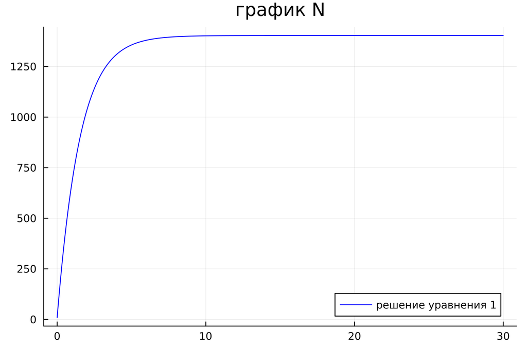

[figure not shown]

2. Случай где
   $$\frac{\partial n}{\partial
   t}=(0.00007+0.7n(t))(N-n(t))$$

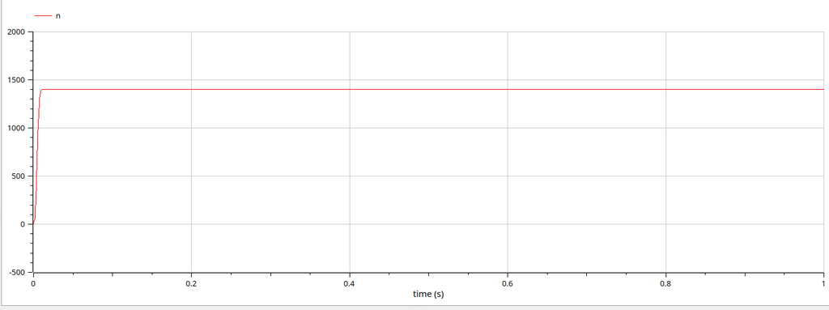

[figure not shown]

3. Случай где
   $$\frac{\partial n}{\partial
   t}=(0.4t+0.3sin(2t)n(t))(N-n(t))$$

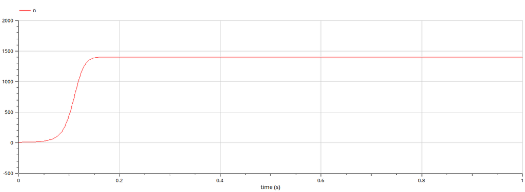

рис3

## Итоговый слайд

- СПАСИБО ЗА ВИНИМАНИЕ